# STATS 330 Assignment 1 2024 SS

Phi Zhang (szha492)

Due date: 23:59 Friday 12th January, 2024

# Background

From assignment:

> This was a five-year research project that investigated the effects of residential treatment for drug abuse. Subjects were randomized to receive either a 3- or 6-month modified therapeutic communities that incorporated elements of health education and relapse prevention. The data set contains the following variables:

> **age:** age at enrollment in years

> **treat:** treatment allocation (0 = Short; and 1 = Long)

> **reuse:** whether return to drug use (1 = Returned to Drug Use; and 0 = Otherwise)

> **ivhx:** IV drug use history (1 = Never; 2 = Previous; and 3 = Recent)

> **ndrugtx:** number of prior drug treatments

# Question One: Draw a graph showing whether the long treatment is more effective in reducing drug reuse, and whether the effectiveness of the treatment depends on age.

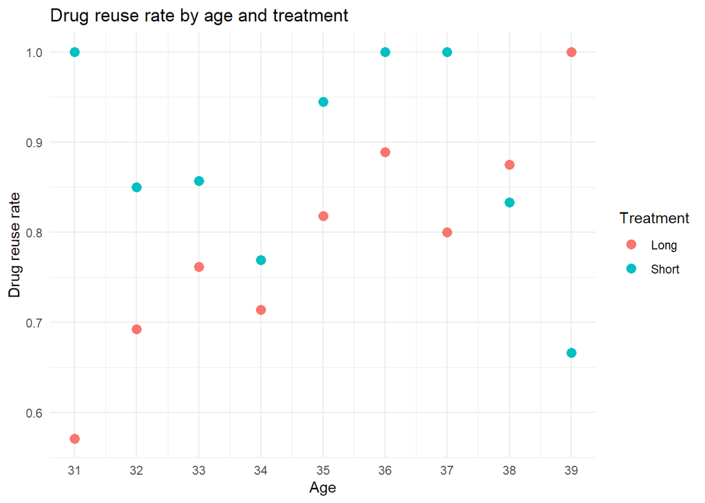

```r
# Read and transform the data
drug_data <- read.csv('drug.csv')
drug_data <- mutate(drug_data,
                    treat=ifelse(treat==1, "Long", "Short"),
                    ivhx = ifelse(ivhx == 1, "Never", ifelse(ivhx == 2, "Previous", "Recent"))
                    )
drug_data$treat <- as.factor(drug_data$treat)
drug_data$ivhx <- as.factor(drug_data$ivhx)

# Group the data
drug_grouped <- drug_data %>%
  select(treat, age, reuse) %>%
  group_by(age, treat) %>%
  summarise(total = n(), n_reuse=sum(reuse), reuse_rate=n_reuse/total, .groups="keep")

# Make the plot
drug_grouped %>% ggplot(aes(x=age, y = reuse_rate, color=treat)) +
  ggtitle("Drug reuse rate by age and treatment") +
  geom_point(size=3) +
  scale_x_continuous(name="Age", breaks=seq(30, 40, by=1)) +
  scale_y_continuous(name="Drug reuse rate") +
  scale_color_discrete(name = "Treatment") +
  theme_minimal()
```

The long treatment appears to be more effective in reducing drug reuse rate, as the probability of reuse tends to be lower. The long treatment is particularly effective for younger participants, but as participants get older, there is less difference in the effectiveness of the treatments. Hence the effectiveness of the treatment appears to depend on age.

# Question Two: Fit an appropriate generalized linear model.

```r
reuse_model <- glm(reuse ~ treat * age, data=drug_data, family='binomial')
summary(reuse_model)
```

```
##
## Call:
## glm(formula = reuse ~ treat * age, family = "binomial", data = drug_data)
##
## Coefficients:
##                Estimate Std. Error z value Pr(>|z|)
## (Intercept)     -7.2658     4.0754  -1.783   0.0746 .
## treatShort      13.5624     5.7440   2.361   0.0182 *
## age              0.2502     0.1202   2.081   0.0374 *
## treatShort:age  -0.3733     0.1663  -2.245   0.0248 *
## ---
## Signif. codes:  0 '***' 0.001 '**' 0.01 '*' 0.05 '.' 0.1 ' ' 1
##
## (Dispersion parameter for binomial family taken to be 1)
##
##     Null deviance: 186.33  on 210  degrees of freedom
## Residual deviance: 176.75  on 207  degrees of freedom
## AIC: 184.75
##
## Number of Fisher Scoring iterations: 4
```

```r
exp(confint(reuse_model))
```

```
##                       2.5 %       97.5 %
## (Intercept)    1.365078e-07 1.449634e+00
## treatShort     1.271893e+01 8.912450e+10
## age            1.027565e+00 1.656149e+00
## treatShort:age 4.912151e-01 9.475299e-01
```

```r
# Model with offset of -32
drug_data$ageoffset <- drug_data$age - 32
reuse_model_offset <- glm(reuse ~ ageoffset * treat, data=drug_data, family='binomial')
summary(reuse_model_offset)
```

```
##
## Call:
## glm(formula = reuse ~ ageoffset * treat, family = "binomial",
##     data = drug_data)
##
## Coefficients:
##                      Estimate Std. Error z value Pr(>|z|)
## (Intercept)            0.7393     0.3404   2.172  0.02989 *
## ageoffset              0.2502     0.1202   2.081  0.03741 *
## treatShort             1.6152     0.5712   2.828  0.00468 **
## ageoffset:treatShort  -0.3733     0.1663  -2.245  0.02479 *
## ---
## Signif. codes:  0 '***' 0.001 '**' 0.01 '*' 0.05 '.' 0.1 ' ' 1
##
## (Dispersion parameter for binomial family taken to be 1)
##
##     Null deviance: 186.33  on 210  degrees of freedom
## Residual deviance: 176.75  on 207  degrees of freedom
## AIC: 184.75
##
## Number of Fisher Scoring iterations: 4
```

```r
exp(confint(reuse_model_offset))
```

```
##                          2.5 %     97.5 %
## (Intercept)          1.0928101  4.2009597
## ageoffset            1.0275651  1.6561493
## treatShort           1.7096413 16.4670268
## ageoffset:treatShort 0.4912151  0.9475299
```

```r
# Model relevelled
drug_data$treat_relevel <- relevel(drug_data$treat, ref = "Short")
reuse_model_relevel <- glm(reuse ~ treat_relevel * age, data=drug_data, family='binomial')
summary(reuse_model_relevel)
```

```
##
## Call:
## glm(formula = reuse ~ treat_relevel * age, family = "binomial",
##     data = drug_data)
##
## Coefficients:
##                       Estimate Std. Error z value Pr(>|z|)
## (Intercept)             6.2966     4.0478   1.556   0.1198
## treat_relevelLong     -13.5624     5.7440  -2.361   0.0182 *
## age                    -0.1232     0.1150  -1.071   0.2840
## treat_relevelLong:age   0.3733     0.1663   2.245   0.0248 *
## ---
## Signif. codes:  0 '***' 0.001 '**' 0.01 '*' 0.05 '.' 0.1 ' ' 1
##
## (Dispersion parameter for binomial family taken to be 1)
##
##     Null deviance: 186.33  on 210  degrees of freedom
## Residual deviance: 176.75  on 207  degrees of freedom
## AIC: 184.75
##
## Number of Fisher Scoring iterations: 4
```

```r
exp(confint(reuse_model_relevel))
```

```
##                              2.5 %       97.5 %
## (Intercept)           2.092561e-01 2.010636e+06
## treat_relevelLong     1.122026e-11 7.862296e-02
## age                   7.023242e-01 1.108982e+00
## treat_relevelLong:age 1.055376e+00 2.035768e+00
```

## 2a: Does the effectiveness of treatment depend on age?

There is evidence that the effectiveness of the treatment depends on age, as the interaction between treatment and age is significant (p-value = 0.0248).

## 2b: For individuals who are 32 years old, which treatment is more effective in reducing drug reuse?

The long treatment is more effective in reducing drug use for individuals who are 32 years old (p-value = 0.00468), as there is evidence that 32 year old individuals given the short treatment are on average 1.71 to 16.47 times more likely to reuse drugs.

## 2c: What is the relationship between age and drug reuse?

For subjects allocated the short treatment, there is no significant relationship between age and drug reuse rate (p-value = 0.2840).

For subjects allocated the long treatment, each 1-year increase in age results on average in a 2.76% to 65.61% increase in drug reuse rate (p-value = 0.0374).

# Question Three: Draw a graph showing how the number of prior drug treatments is related to the IV drug use history and the age of participants.

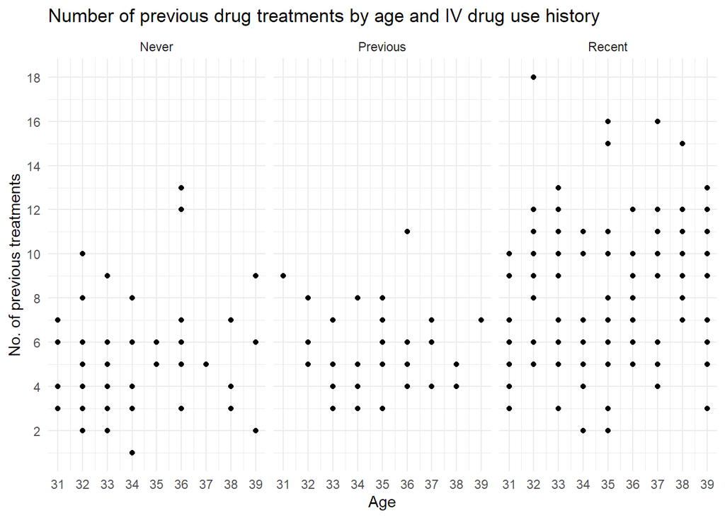

```r
# Draw the plot
ggplot(drug_data, aes(x=age, y=ndrugtx)) +
  ggtitle("Number of previous drug treatments by age and IV drug use history") +
  geom_point() +
  scale_x_continuous(name = "Age", breaks=seq(30,40)) +
  scale_y_continuous(name = "No. of previous treatments", breaks=seq(0, 20, by=2)) +
  facet_wrap(~ivhx) +
  theme_minimal()
```

Participants who had recently used IV drugs appear to have had higher numbers of previous treatments than the other two groups. There is more scatter in the plot, indicating a wider variety of number of previous treatments for all ages. There appears to be a slight positive association between age and number of previous treatments.

Participants who had previously used IV drugs appear to have a similar range of number of previous drug treatments to those who had never used IV drugs. There does not appear to be much association between age and number of previous treatments.

Participants who had never used IV drugs may have a slight positive association between age and number of previous treatments, but it is unclear.

# Question Four: Build an appropriate generalized linear model to explain how the number of prior drug treatments is related to the IV drug use history and the age of participants.

```r
prior_treatments_model <- glm(ndrugtx ~ ivhx * age, family = "poisson", data=drug_data)
summary(prior_treatments_model)
```

```
##
## Call:
## glm(formula = ndrugtx ~ ivhx * age, family = "poisson", data = drug_data)
##
## Coefficients:
##                   Estimate Std. Error z value Pr(>|z|)
## (Intercept)       0.818500   0.823931   0.993    0.321
## ivhxPrevious      0.943302   1.453351   0.649    0.516
## ivhxRecent        0.252455   0.936718   0.270    0.788
## age               0.024189   0.024201   1.000    0.318
## ivhxPrevious:age -0.024021   0.041991  -0.572    0.567
## ivhxRecent:age    0.006135   0.027314   0.225    0.822
##
## (Dispersion parameter for poisson family taken to be 1)
##
##     Null deviance: 299.69  on 210  degrees of freedom
## Residual deviance: 221.48  on 205  degrees of freedom
## AIC: 1017.1
##
## Number of Fisher Scoring iterations: 4
```

```r
# New model without the insignificant interaction term
prior_treatments_model_2 <- glm(ndrugtx ~ ivhx + age, family = "poisson", data=drug_data)
summary(prior_treatments_model_2)
```

```
##
## Call:
## glm(formula = ndrugtx ~ ivhx + age, family = "poisson", data = drug_data)
##
## Coefficients:
##              Estimate Std. Error z value Pr(>|z|)
## (Intercept)   0.75016    0.36637   2.048   0.0406 *
## ivhxPrevious  0.10353    0.09038   1.146   0.2520
## ivhxRecent    0.46547    0.06597   7.056 1.72e-12 ***
## age           0.02620    0.01065   2.459   0.0139 *
## ---
## Signif. codes:  0 '***' 0.001 '**' 0.01 '*' 0.05 '.' 0.1 ' ' 1
##
## (Dispersion parameter for poisson family taken to be 1)
##
##     Null deviance: 299.69  on 210  degrees of freedom
## Residual deviance: 222.17  on 207  degrees of freedom
## AIC: 1013.8
##
## Number of Fisher Scoring iterations: 4
```

```r
anova(prior_treatments_model_2, test="Chisq")
```

```
## Analysis of Deviance Table
##
## Model: poisson, link: log
##
## Response: ndrugtx
##
## Terms added sequentially (first to last)
##
##
##      Df Deviance Resid. Df Resid. Dev  Pr(>Chi)
## NULL                   210     299.69
## ivhx  2   71.500       208     228.19 2.979e-16 ***
## age   1    6.024       207     222.17   0.01412 *
## ---
## Signif. codes:  0 '***' 0.001 '**' 0.01 '*' 0.05 '.' 0.1 ' ' 1
```

```r
# Goodness-of-fit
1 - pchisq(deviance(prior_treatments_model), prior_treatments_model$df.residual)
```

```
## [1] 0.2044994
```

```r
# Confidence intervals
exp(confint(prior_treatments_model_2))
```

```
##                  2.5 %   97.5 %
## (Intercept)  1.0322984 4.340987
## ivhxPrevious 0.9279398 1.322741
## ivhxRecent   1.4013828 1.815120
## age          1.0053002 1.048181
```

```r
# Relevelling
prior_treatments_model_2_relevel <- glm(ndrugtx ~ relevel(ivhx, ref="Previous") + age, family = "poisson", data=drug_data)
summary(prior_treatments_model_2_relevel)
```

```
##
## Call:
## glm(formula = ndrugtx ~ relevel(ivhx, ref = "Previous") + age,
##     family = "poisson", data = drug_data)
##
## Coefficients:
##                                       Estimate Std. Error z value Pr(>|z|)
## (Intercept)                            0.85369    0.37874   2.254   0.0242 *
## relevel(ivhx, ref = "Previous")Never  -0.10353    0.09038  -1.146   0.2520
## relevel(ivhx, ref = "Previous")Recent  0.36194    0.07688   4.708  2.5e-06 ***
## age                                    0.02620    0.01065   2.459   0.0139 *
## ---
## Signif. codes:  0 '***' 0.001 '**' 0.01 '*' 0.05 '.' 0.1 ' ' 1
##
## (Dispersion parameter for poisson family taken to be 1)
##
##     Null deviance: 299.69  on 210  degrees of freedom
## Residual deviance: 222.17  on 207  degrees of freedom
## AIC: 1013.8
##
## Number of Fisher Scoring iterations: 4
```

```r
exp(confint(prior_treatments_model_2_relevel))
```

```
##                                           2.5 %   97.5 %
## (Intercept)                           1.1177400 4.933795
## relevel(ivhx, ref = "Previous")Never  0.7560057 1.077656
## relevel(ivhx, ref = "Previous")Recent 1.2381794 1.673943
## age                                   1.0053002 1.048181
```

As age increases and with IV drug use history held constant, a participant’s number of prior drug treatments increases on average by between 0.53% and 4.82%.

Participants at the same age who had recently used IV drugs had on average between 40.14% to 81.51% more previous drug treatments than participants who had never used IV drugs (p-value < 0.0001).

Participants at the same age who had recently used IV drugs had on average between 23.82% and 67.39% more previous drug treatments than participants who had previously used IV drugs (p-value < 0.0001).

There was no significant difference in number of previous drug treatments between participants of the same age who had previously used IV drugs and had never used IV drugs.